# S5_Informe Final - P4

### **Tema**

Las condiciones que determinan el daño por segundo de las armas en el juego Warzone

### **Introducción**

Warzone es una battle royale gratuito disponible para plataformas como PC, Play Station y Xbox, y te permite jugar con personas desde otras plataformas como las previamente mencionadas. Además, cuenta con una comunidad de aproximadamente 85 millones de jugadores. Lo interesante del juego es que tiene nuevas mecánicas que lo diferencian de sus rivales como Fornite o PUBG, las cuales generan un atractivo muy influyente en los jugadores. Una de ellas es Gulag, este término hace referencia a una segunda oportunidad dentro del juego una vez que hayas sido abatido por un enemigo. Este consiste en un enfrentamiento entre otros jugadores abatidos dentro de la partida con una temática muy simple y clara, quien gana dicho enfrentamiento revive, y el otro jugador sigue en modo ‘espera’ hasta que sus compeñeros vayan a una tienda y paguen para que regrese al juego.

### **Objetivos**

**Objetivo General**

- El objetivo de esta investigación es analizar el método de juego dentro de Warzone. De esta manera, vamos a poder reconocer las cualidades de las armas que generan que un jugador pueda ganar un enfrentamiento.

**Objetivos Específicos**

- Encontrar la correlación entre los diversos factores que influyen en el daño por segundo de las armas.

- Identificar los principales factores que afectan y desbalancean el daño por segundo de las armas.

### **Plan de muestreo**

**Muestra:** Indicadores del desempeño de las armas dentro del juego Warzone

**Tipo y tamaño de la muestra:** Muestreo por juicio (150 observaciones)

**Unidad muestral:** Armas dentro del juego Warzone

**Metodología:** Extraer la información de la base de datos (en formato csv) pública del analista TrueGameData. Además, se realizará un experimento dentro del juego para hallar el retroceso de todas las armas en estudio.

**Público objetivo:** Fanáticos del juego Warzone

### **Limpieza de Datos**

Se agregó la columna ‘Tipo’ para identificar a qué categoría pertenece cada arma y se cambió el encabezado de la segunda columna a ‘Arma’ para todas las bases de datos que tenemos. Después, las colocamos todas dentro de una sola, llamada ‘DF’ ya que de esta manera podemos realizar las comparaciones de una mejor forma.

### **Experimento Retroceso**

El experimento se realizó mediante la consola PS4. Dentro del juego, se ubicó al jugador frente a una pared a una distancia menor a la de su rango de daño máximo, logrando que el experimento sea lo más justo posible para cada arma. Luego, se realizó 5 ráfagas de disparos por cada arma, de esta manera se pudo categorizar el retroceso de cada una de ellas, estableciendo una escala del 0 al 10, donde 0 significa que el arma prácticamente no tiene retroceso y el 10 significa que tiene un retroceso incontrolable. Los criterios que utilizamos para establecer la escala de todas las armas son la apreciación de un jugador experto (un integrante del grupo) y la tendencia que generan los disparos. Con respecto al último criterio mencionado, se tuvo en cuenta si es que los disparos originaron una curva hacia la izquierda o derecha, un movimiento “zigzag”, o una línea relativamente recta. Es importante mencionar que todas las armas cuerpo a cuerpo tienen un valor de 0 en la escala de retroceso debido a que el jugador acompaña la trayectoria del ataque asegurando la precisión del arma. Esta información es de mucha ayuda para el jugador ya que podrá predecir el movimiento de sus disparos, aprovechando al máximo el arma utilizada.

[figure not shown]

### **Clasificación de variables**

Contamos con 10 variables en total, 7 numéricas y 3 categóricas.

**Variables Numéricas**

| Variable | Tipo de Variable | Restricciones |
| --- | --- | --- |
| Rango de Daño Máximo (m) | Continua | Entero no negativo |
| Daño extremidades | Discreta | Entero no negativo |
| Daño Torso inferior | Discreta | Entero no negativo |
| Daño torso superior | Discreta | Entero no negativo |
| Balas por minuto | Discreta | Entero no negativo |
| Daño por segundo | Discreta | Entero no negativo |
| Daño a la cabeza | Discreta | Entero no negativo |

**Variables Categóricas**

| Variable | Tipo de Variable | Restricciones |
| --- | --- | --- |
| Retroceso | Ordinal | Entre 0 y 10 |
| Arma | Nominal | - |
| Tipo | Nominal | - |

### **Análisis descriptivo**

### *Daño por segundo*

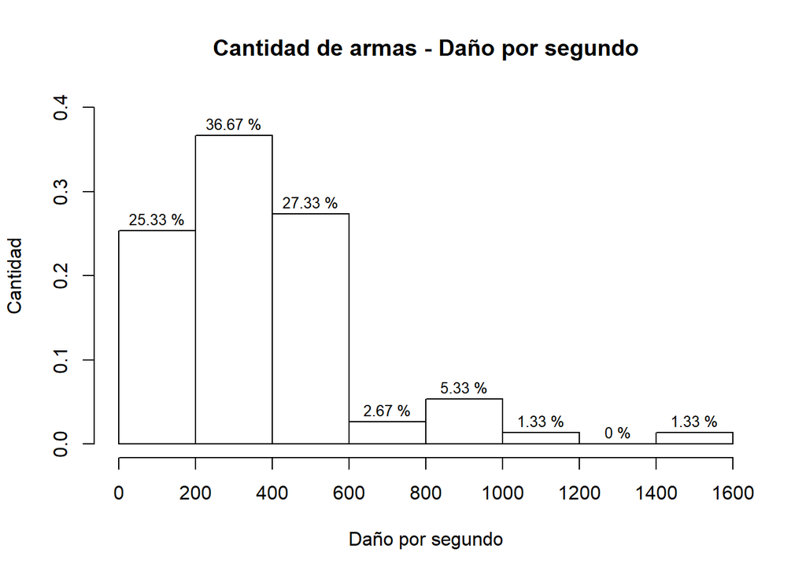

En el histograma se puede observar que la mayor cantidad de armas, 89.33% del total, se concentran entre 0 y 600, lo cual nos indica que existen pocas armas con un alto valor de daño por segundo, siendo solo 2 armas (1.33%) las que tienen un valor mayor a 1400.

### *Daño por segundo* y *Tipo*

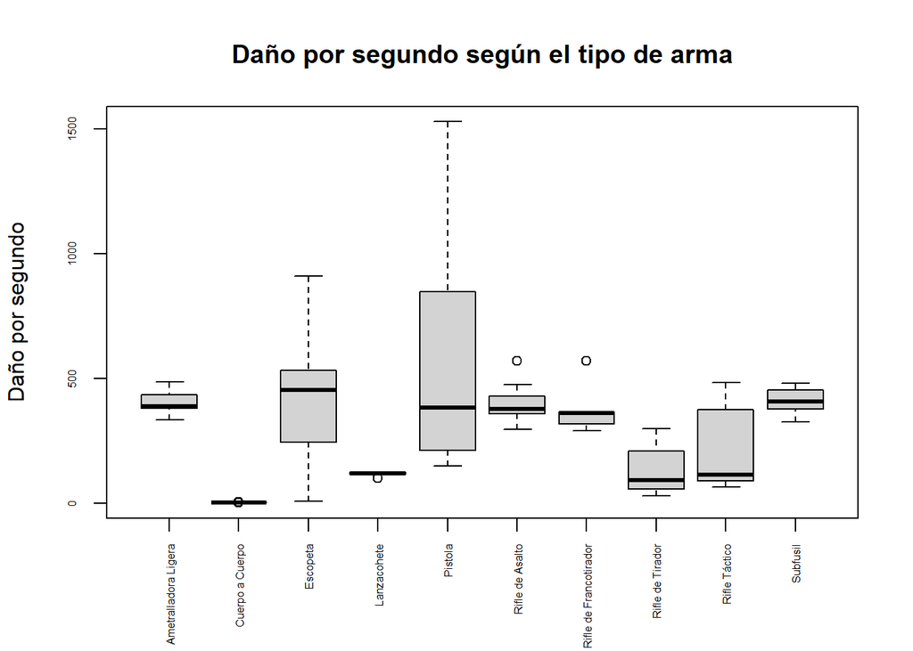

```
## [1] "Pistolas"
```

```
## [1] "Desviación estándar: 418.18"
```

```
## [1] "Media: 586.19"
```

```
## [1] "Mediana: 382"
```

```
## [1] "Rango Intercuartílico: 636.5"
```

```
##     0%    25%    50%    75%   100%
##  149.0  212.0  382.0  848.5 1529.0
```

```r
cv1 <- sd(AL$`Daño por segundo`)
cv2 <- sd(CC$`Daño por segundo`)
cv3 <- sd(E$`Daño por segundo`)
cv4 <- sd(LC$`Daño por segundo`)
cv5 <- sd(MR$`Daño por segundo`)
cv6 <- sd(P$`Daño por segundo`)
cv7 <- sd(RA$`Daño por segundo`)
cv8 <- sd(RF$`Daño por segundo`)
cv9 <- sd(RT$`Daño por segundo`)
cv10 <- sd(SF$`Daño por segundo`)
tipos <- c("Ametralladoras Ligeras", "Armas Cuerpo a Cuerpo", "Escopetas", "Lanzacohetes", "Marksman Rifle", "Pistolas", "Rifles de Asalto", "Rifles de Francotirador", "Rifles Tácticos", "Subfusiles")
desv <- c(cv1,cv2,cv3,cv4,cv5,cv6,cv7,cv8,cv9,cv10)
desv <- round(desv,2)
tabla <- data.frame(Tipo=tipos,desviacion.estandar=desv)
tabla <- tabla[ order(tabla$desviacion.estandar), ]
tabla
```

|  | Tipo | desviacion.estandar |
| --- | --- | --- |
| 2 | Armas Cuerpo a Cuerpo | 1.30 |
| 4 | Lanzacohetes | 9.09 |
| 10 | Subfusiles | 45.31 |
| 1 | Ametralladoras Ligeras | 49.18 |
| 7 | Rifles de Asalto | 56.58 |
| 5 | Marksman Rifle | 101.50 |
| 8 | Rifles de Francotirador | 110.56 |
| 9 | Rifles Tácticos | 166.45 |
| 3 | Escopetas | 250.89 |
| 6 | Pistolas | 418.18 |

Mediante este boxplot se analiza la relación entre el daño por segundo y el tipo de arma. Se puede destacar que las pistolas son la armas que tienen un mayor rango intercuartílico; es decir, que el 50% de las observaciones varían entre 212 y 848.5. Además, se puede observar que el tamaño de las cajas varía de acuerdo con los tipos de armas, esto se evidencia mediante la desviación estándar calculada y ordenada en la tabla. Adicionalmente, al observar que la media es mayor a la mediana, podemos concluir que las observaciones presentan un sesgo hacia la derecha. La gráfica indica que no necesariamente el tipo de arma influye en la cantidad de daño por segundo.

Nota: Rifles de Francotirador y Rifles de Tirador son distintos ya que requieren que se active el cerrojo manualmente para disparar y se realiza a una larga distancia. Por otro lado, el segundo tipo de arma es semiautomático; es decir, por cada tirón del gatillo, se dispara una sola bala.

### *Tipo*

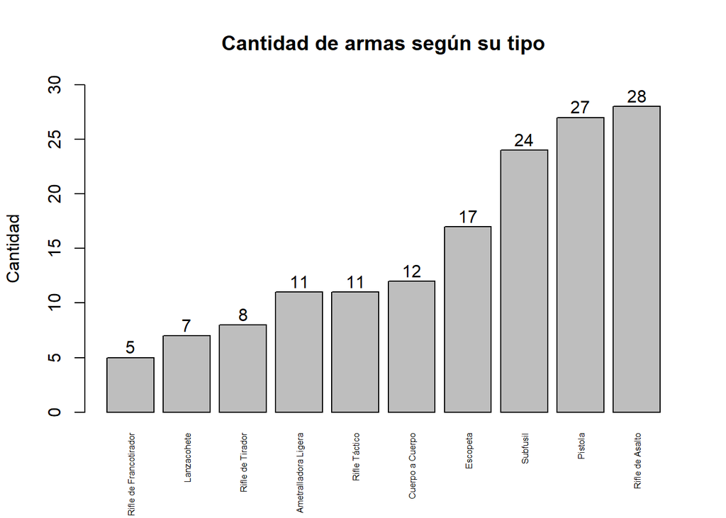

En este barplot podemos verificar que las Pistolas y Rifles de Asalto tienen una mayor cantidad de armas dentro de nuestra base de datos. Esto lo podemos relacionar con el gráfico anterior porque las pistolas al tener una alta variabilidad y gran cantidad de armas, nos indica que la dispersión es bastante amplia. Además, se puede observar que el Lanzacohete y el Rifle de Francotirador son aquellos tipos de armas que tiene las menores cantidades. En líneas generales, podemos afirmar que no existe una proporcionalidad de acuerdo con el tipo de arma.

### *Rango de Daño Máximo*

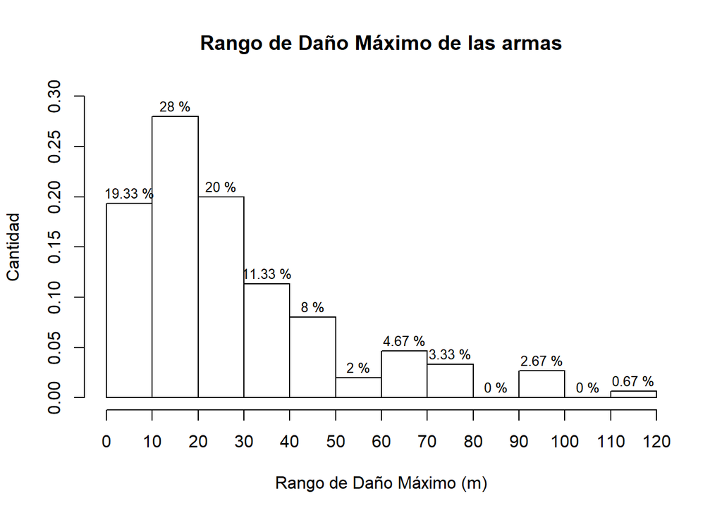

```r
DF[which.max(DF$`Rango de Daño Máximo (m)`),]
```

|  | Tipo | Arma | Rango de Daño Máximo (m) | Daño extremidades | Daño Torso inferior | Daño torso superior | Balas por minuto | Daño por segundo | Daño a la cabeza | Retroceso |
| --- | --- | --- | --- | --- | --- | --- | --- | --- | --- | --- |
| 126 | Rifle Táctico | ZRG 20mm | 115 | 91 | 117 | 126 | 43 | 90 | 250 | 2 |

El histograma muestra que el rango de daño máximo está entre 0 y 120 metros. Además, la mayor cantidad de armas se encuentran dentro de los primeros intervalos, es decir; entre 0 y 50 metros, lo que representa el 86.66% de los datos. Por otro lado, solo 5 armas son las que superan los 90 metros, y dentro de ellas solo 1 arma, específicamente un Rifle Táctico logra llegar a los 115 metros. Cabe mencionar que la variable en análisis representa la distancia a la cual el arma va a poder generar su mayor poder.

### *Retroceso*

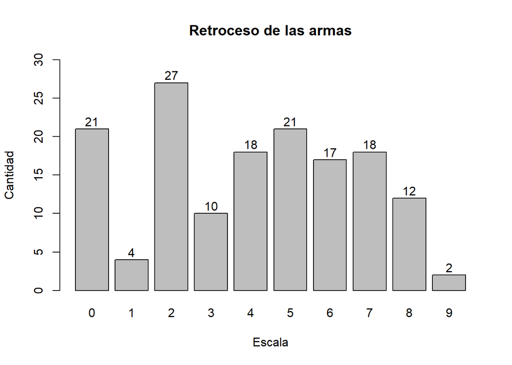

```r
a <- DF[DF$Retroceso == 0, ]
table(a$Tipo)
```

```
##
## Cuerpo a Cuerpo     Lanzacohete Rifle de Asalto
##              12               7               2
```

Después de realizar el experimento dentro del juego, se evidencia que las cantidades son un tanto proporcionales con ciertas tendencias descendentes que son los valores de la escala 1 y 9. Además, la mayor cantidad de armas tienen una escala de 2. Por otra parte, solo 3 tipos de armas cuentan con un retroceso de 0, lo que significa que el arma tiene buena precisión de ataque. Estas son las armas Cuerpo a Cuerpo, Lanzacohetes y Rifles de Asalto.

### *Daño a la cabeza* y *Daño extremidades*

```
##            (Intercept) DF$`Daño extremidades`
##                  34.58                   1.07
```

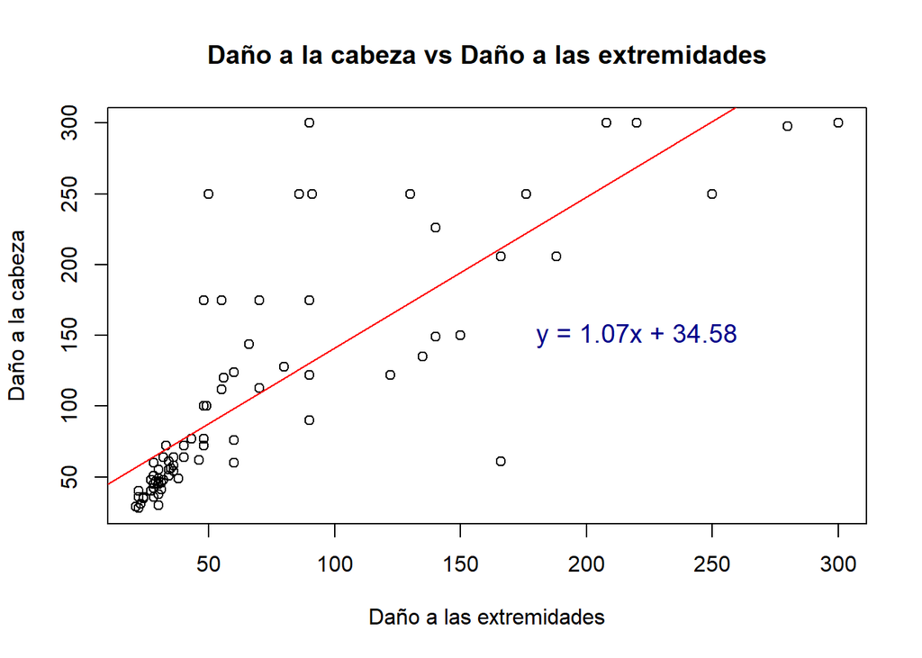

```
##
## Call:
## lm(formula = DF$`Daño a la cabeza` ~ DF$`Daño extremidades`)
##
## Residuals:
##     Min      1Q  Median      3Q     Max
## -150.73  -23.99  -15.63   11.86  169.38
##
## Coefficients:
##                        Estimate Std. Error t value Pr(>|t|)
## (Intercept)            34.57938    6.21008   5.568 1.18e-07 ***
## DF$`Daño extremidades`  1.06716    0.06325  16.871  < 2e-16 ***
## ---
## Signif. codes:  0 '***' 0.001 '**' 0.01 '*' 0.05 '.' 0.1 ' ' 1
##
## Residual standard error: 47.43 on 148 degrees of freedom
## Multiple R-squared:  0.6579, Adjusted R-squared:  0.6556
## F-statistic: 284.6 on 1 and 148 DF,  p-value: < 2.2e-16
```

```r
cor(DF$`Daño a la cabeza`,DF$`Daño extremidades`)
```

```
## [1] 0.8111217
```

Intervalo de confianza con un nivel de confianza del 99 %.

```r
Zcritica <- qnorm(0.01/2, lower.tail = FALSE)
izq <- 1.06716 - (Zcritica*0.06325)
der <- 1.06716 + (Zcritica*0.06325)
cat("(",izq,",",der,")")
```

```
## ( 0.9042388 , 1.230081 )
```

La gráfica muestra que posiblemente exista una correlación positiva entre las variables ‘Daño a la cabeza’ y ‘Daño a las extremidades’. Al calcular el coeficiente de correlación entre las variables, este nos da un valor de 0.811 y justifica lo mencionado anteriormente. Además, se aprecia mediante la regresión lineal, el ajuste de las observaciones a este modelo. En este caso, la línea roja modela cuál sería el valor del daño a la cabeza si es que solo conocemos el daño en las extremidades. Entonces, mientras más puntos estén cerca a la línea roja, significa que el modelo se ajusta de mejor manera a los datos recolectados.

```
##              (Intercept) DF$`Daño Torso inferior`
##                     4.72                     1.00
```

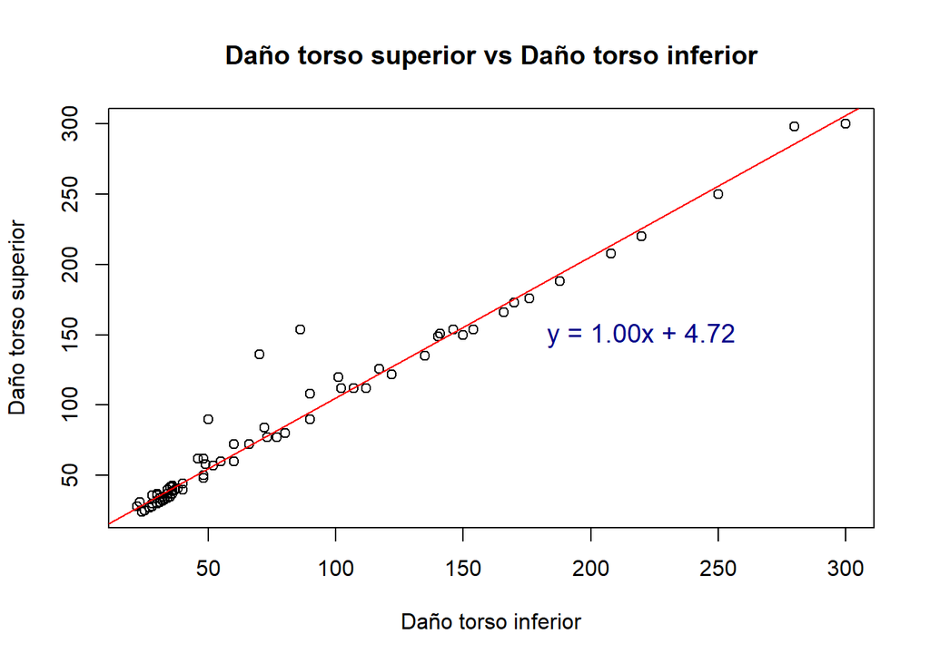

```
##
## Call:
## lm(formula = DF$`Daño torso superior` ~ DF$`Daño Torso inferior`)
##
## Residuals:
##    Min     1Q Median     3Q    Max
## -6.036 -4.895 -4.825  2.125 62.903
##
## Coefficients:
##                          Estimate Std. Error t value Pr(>|t|)
## (Intercept)               4.72000    1.27170   3.712 0.000291 ***
## DF$`Daño Torso inferior`  1.00439    0.01273  78.910  < 2e-16 ***
## ---
## Signif. codes:  0 '***' 0.001 '**' 0.01 '*' 0.05 '.' 0.1 ' ' 1
##
## Residual standard error: 9.532 on 148 degrees of freedom
## Multiple R-squared:  0.9768, Adjusted R-squared:  0.9766
## F-statistic:  6227 on 1 and 148 DF,  p-value: < 2.2e-16
```

```r
cor(DF$`Daño torso superior`,DF$`Daño Torso inferior`)
```

```
## [1] 0.9883236
```

Intervalo de confianza con un nivel de confianza del 99 %.

```r
Zcritica <- qnorm(0.01/2, lower.tail = FALSE)
izq <- 1.00439 - (Zcritica*0.01273)
der <- 1.00439 + (Zcritica*0.01273)
cat("(",izq,",",der,")")
```

```
## ( 0.9715997 , 1.03718 )
```

En este gráfico, se evidencia una relación lineal positiva entre las variables ‘Daño torso superior’ y ‘Daño torso inferior’, con un coeficiente de correlación de 0.988. Por su parte, la pendiente de la ecuación lineal es 1.004 y el intercepto es de 4.72.

### *Daño extremidades* y *Daño torso superior*

```
##              (Intercept) DF$`Daño torso superior`
##                    -4.92                     0.97
```

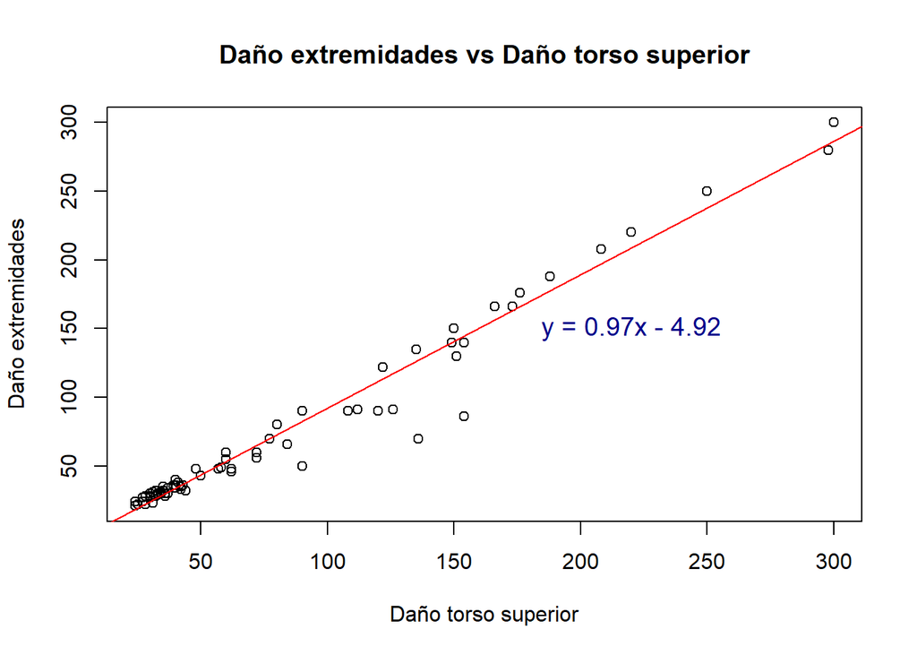

```
##
## Call:
## lm(formula = DF$`Daño extremidades` ~ DF$`Daño torso superior`)
##
## Residuals:
##     Min      1Q  Median      3Q     Max
## -58.661  -2.874   2.340   6.033  13.526
##
## Coefficients:
##                          Estimate Std. Error t value Pr(>|t|)
## (Intercept)               -4.9218     1.4224   -3.46 0.000705 ***
## DF$`Daño torso superior`   0.9713     0.0136   71.40  < 2e-16 ***
## ---
## Signif. codes:  0 '***' 0.001 '**' 0.01 '*' 0.05 '.' 0.1 ' ' 1
##
## Residual standard error: 10.35 on 148 degrees of freedom
## Multiple R-squared:  0.9718, Adjusted R-squared:  0.9716
## F-statistic:  5098 on 1 and 148 DF,  p-value: < 2.2e-16
```

```r
cor(DF$`Daño extremidades`,DF$`Daño torso superior`)
```

```
## [1] 0.9857922
```

Intervalo de confianza con un nivel de confianza del 99 %.

```r
Zcritica <- qnorm(0.01/2, lower.tail = FALSE)
izq <- 0.9713 - (Zcritica*0.0136)
der <- 0.9713 + (Zcritica*0.0136)
cat("(",izq,",",der,")")
```

```
## ( 0.9362687 , 1.006331 )
```

### *Daño extremidades* y *Daño torso inferior*

```
##              (Intercept) DF$`Daño Torso inferior`
##                     -2.2                      1.0
```

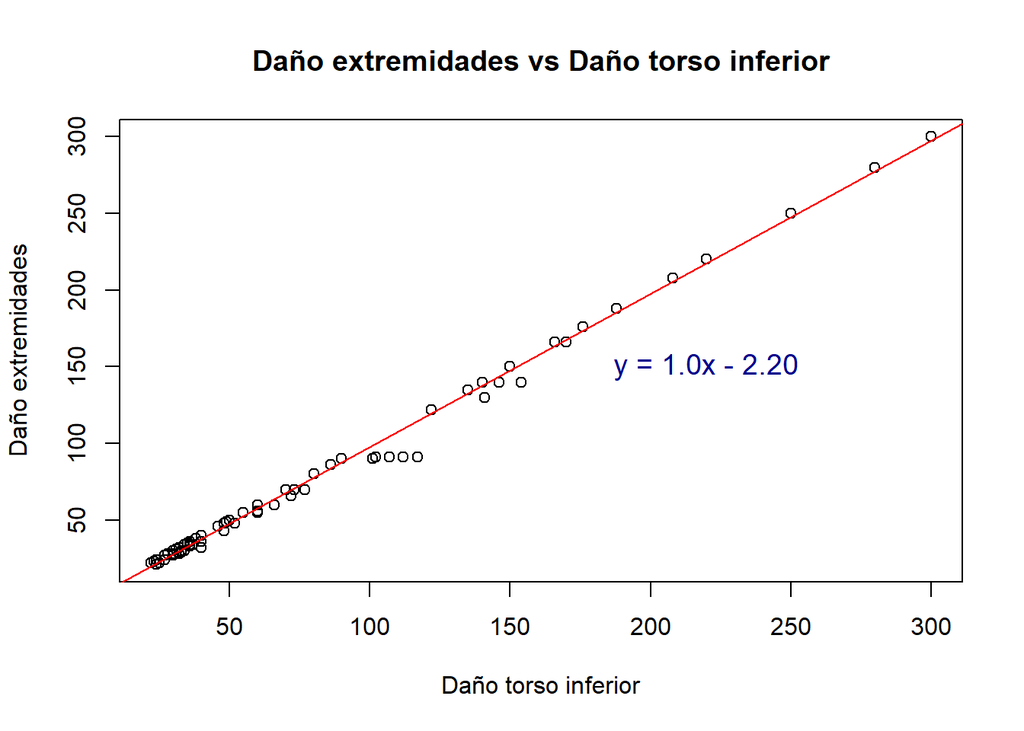

```
##
## Call:
## lm(formula = DF$`Daño extremidades` ~ DF$`Daño Torso inferior`)
##
## Residuals:
##     Min      1Q  Median      3Q     Max
## -23.700  -1.436   2.225   2.276   2.460
##
## Coefficients:
##                           Estimate Std. Error t value Pr(>|t|)
## (Intercept)              -2.197573   0.545762  -4.027 9.01e-05 ***
## DF$`Daño Torso inferior`  0.999126   0.005462 182.908  < 2e-16 ***
## ---
## Signif. codes:  0 '***' 0.001 '**' 0.01 '*' 0.05 '.' 0.1 ' ' 1
##
## Residual standard error: 4.091 on 148 degrees of freedom
## Multiple R-squared:  0.9956, Adjusted R-squared:  0.9956
## F-statistic: 3.346e+04 on 1 and 148 DF,  p-value: < 2.2e-16
```

```r
cor(DF$`Daño extremidades`,DF$`Daño Torso inferior`)
```

```
## [1] 0.9977954
```

Intervalo de confianza con un nivel de confianza del 99 %.

```r
Zcritica <- qnorm(0.01/2, lower.tail = FALSE)
izq <- 0.999126 - (Zcritica*0.005462)
der <- 0.999126 + (Zcritica*0.005462)
cat("(",izq,",",der,")")
```

```
## ( 0.9850568 , 1.013195 )
```

De manera muy similar que en los casos anteriores, se puede observar que existe una relación lineal positiva entre las variables ‘Daño extremidades’ y ‘Daño torso inferior’ con un coeficiente de correlación de 0.998. Por otro lado, la pendiente es de 1 y tiene un intercepto de -2.20.

### *Daño a la cabeza* y *Daño torso superior*

```
##              (Intercept) DF$`Daño torso superior`
##                    22.04                     1.12
```

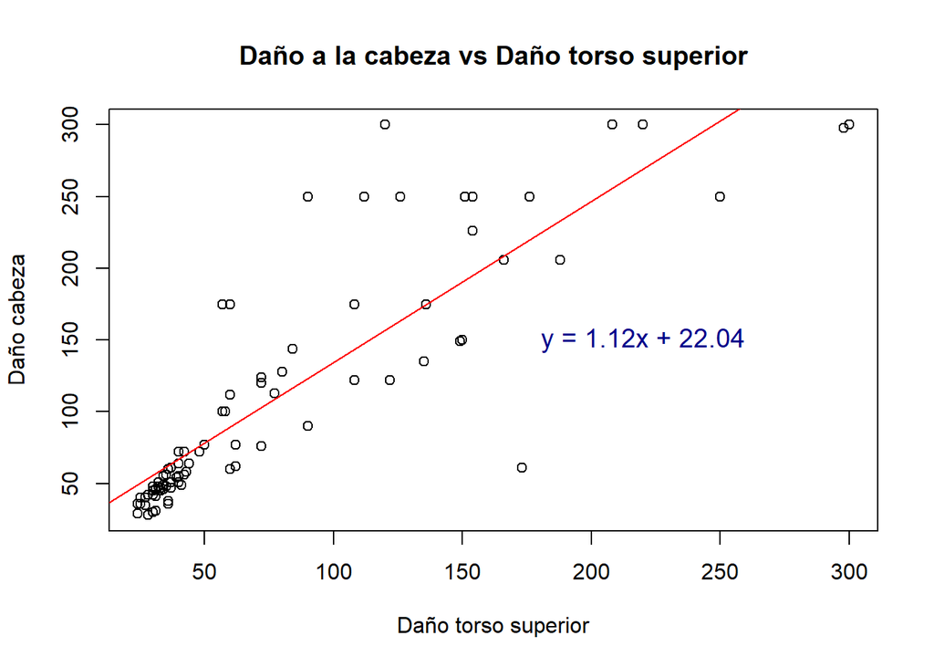

```
##
## Call:
## lm(formula = DF$`Daño a la cabeza` ~ DF$`Daño torso superior`)
##
## Residuals:
##     Min      1Q  Median      3Q     Max
## -155.36  -19.09  -10.12   10.87  143.17
##
## Coefficients:
##                          Estimate Std. Error t value Pr(>|t|)
## (Intercept)               22.0405     5.5623   3.962 0.000115 ***
## DF$`Daño torso superior`   1.1232     0.0532  21.113  < 2e-16 ***
## ---
## Signif. codes:  0 '***' 0.001 '**' 0.01 '*' 0.05 '.' 0.1 ' ' 1
##
## Residual standard error: 40.49 on 148 degrees of freedom
## Multiple R-squared:  0.7507, Adjusted R-squared:  0.749
## F-statistic: 445.7 on 1 and 148 DF,  p-value: < 2.2e-16
```

```r
cor(DF$`Daño a la cabeza`,DF$`Daño torso superior`)
```

```
## [1] 0.8664488
```

Intervalo de confianza con un nivel de confianza del 99 %.

```r
Zcritica <- qnorm(0.01/2, lower.tail = FALSE)
izq <- 1.1232 - (Zcritica*0.0532)
der <- 1.1232 + (Zcritica*0.0532)
cat("(",izq,",",der,")")
```

```
## ( 0.9861659 , 1.260234 )
```

Se evidencia una correlación positiva con un coeficiente de correlación de 0.866 entre las variables ‘Daño a la cabeza’ y ‘Daño torso superior’. La pendiente y el intercepto para este caso son 1.123 y 22.041 respectivamente.

### **Patrón del juego**

Tras realizar los intervalos de confianza para todas las pendientes a un 99 %, podemos tomar un valor de 1 para todas ellas ya que está dentro del intervalo de confianza y además, es consistente para ayudarnos a encontrar un patrón. Por lo tanto, que la pendiente sea igual a 1 en todas las regresiones, nos indica que lo que modifica el daño en las diferentes zonas del cuerpo para todas las armas, se ve afectada principalmente por el intercepto.

```
                                            DC = Daño a la cabeza

                                            DE = Daño extremidades

                                            DTS = Daño torso superior

                                            DTI = Daño torso inferior
```

Procedemos a colocar las ecuaciones.

```
                                            DC = DE + 34.58

                                            DTS = DTI + 4.72

                                            DE = DTS - 4.92

                                            DE = DTI - 2.20

                                            DC = DTS + 22.04
```

Por lo tanto podemos decir que:

```
                                            DC > DE

                                            DTS > DTI

                                            DTS > DE

                                            DTI > DE

                                            DC > DTS
```

Después de haber analizado las ecuaciones y ordenado las regresiones, identificamos que se cumple la siguiente relación:

```
                                        DC > DTS > DTI > DE
```

Esto nos indica que dentro del juego, siempre es preferible atacar siguiendo esta regla de priorización para realizar un mayor daño a tu oponente.

Nota: Dentro del estudio, ningún arma es explosiva, por lo que el daño realizado se dirige a una zona específica del cuerpo del oponente (cabeza, extremidades, torso superior, torso inferior).

### **Variable aleatoria discreta**

Caso: Si saco 10 armas al azar de nuestra base de datos, cuál es la probabilidad de que tengan un daño por segundo mayor a 500.

```r
#cálculo de la probabilidad de que un arma tenga un daño por segundo mayor a 500
p <- sum(DF$`Daño por segundo` >= 500) / length(DF$`Daño por segundo`)
paste("Probabilidad:", p)
```

```
## [1] "Probabilidad: 0.146666666666667"
```

```r
r <- pbinom(1,size = 10,prob = p, lower.tail = FALSE)
paste("Probabilidad:", r)# la probabilidad de que más de 1 arma en un grupo de 10 sacadas al azar, tengan un daño por segundo mayor o igual a 500
```

```
## [1] "Probabilidad: 0.44338311028514"
```

Podemos concluir que la probabilidad para que de 10 armas escogidas al azar, obtenga más de una con un daño por segundo mayor o igual a 500 es de 0.443.

### **Pruebas de Hipótesis**

> **1.- ¿La media del daño por segundo de las armas es 300? Se requiere determinar la hipótesis con un nivel de confianza del 95 %.**

En función al gráfico de cantidad de armas vs daño por segundo, se ve que la mayor cantidad de armas, tienen un daño por segundo dentro del intervalo de 200 a 400, por lo que la hipótesis se relaciona con la aproximación inferida sobre un daño por segundo de 300.

H0: La media del daño por segundo es 300.

Ha: La media del daño por segundo no es 300.

Mi región de rechazo es $(-\infty, -Z_{critica}) \cup (Z_{critica}, \infty)$

```r
Zcritica <- qnorm(0.05/2, lower.tail = FALSE)
Zcritica
```

```
## [1] 1.959964
```

Planteamos nuestro intervalo de confianza:

```r
sigma <- sd(DF$`Daño por segundo`)
n <- length(DF$`Daño por segundo`)
x <- mean(DF$`Daño por segundo`)
izq <- x - Zcritica*(sigma/sqrt(n))
der <- x + Zcritica*(sigma/sqrt(n))

cat("(",izq,",",der,")")
```

```
## ( 322.6521 , 406.5746 )
```

```r
t.test(DF$`Daño por segundo`, mu = 300, alternative = "two.sided", conf.level = 0.95)
```

```
##
##  One Sample t-test
##
## data:  DF$`Daño por segundo`
## t = 3.018, df = 149, p-value = 0.002994
## alternative hypothesis: true mean is not equal to 300
## 95 percent confidence interval:
##  322.3085 406.9182
## sample estimates:
## mean of x
##  364.6133
```

Se rechaza la hipótesis nula puesto que 300 no se encuentra dentro del intervalo de confianza. Además, caemos en la región de rechazo por lo que confirmamos que se rechaza la hipótesis nula. Finalmente, el valor de p-value es menor a la significancia (0.05), por lo que existe suficiente evidencia estadística para confirmar que la media del daño por segundo difiere de 300.

> **2.- ¿La media del daño por segundo de las armas ‘Rifles de Asalto’ es igual de aquellas que son ‘Rifles de Francotirador’? Se requiere determinar la hipótesis con un nivel de confianza del 95 %.**

Estos dos tipos de armas tienen las medias similares, por lo que es interesante analizar si la segmentación propia del juego, tiene alguna relevancia con su desempeño.

H0: Las medias del daño por segundo son iguales.

Ha: Las medias del daño por segundo no son iguales.

Mi región de rechazo es $(-\infty, -Z_{critica}) \cup (Z_{critica}, \infty)$

```r
Zcritica <- qnorm(0.05/2, lower.tail = FALSE)
Zcritica
```

```
## [1] 1.959964
```

```r
t.test(
  x           = RA$`Daño por segundo`,
  y           = RF$`Daño por segundo`,
  alternative = "two.sided",
  mu          = 0,
  conf.level  = 0.95
)
```

```
##
##  Welch Two Sample t-test
##
## data:  RA$`Daño por segundo` and RF$`Daño por segundo`
## t = 0.27874, df = 4.3814, p-value = 0.7931
## alternative hypothesis: true difference in means is not equal to 0
## 95 percent confidence interval:
##  -121.6543  149.8543
## sample estimates:
## mean of x mean of y
##     395.5     381.4
```

> **3.- ¿La media del daño en la cabeza para los ‘Rifles de Tirador’ es mayor igual que para las ‘Escopetas’? Se requiere determinar la hipótesis con un nivel de confianza del 95 %.**

Al haber hallado que el daño a la cabeza es la prioridad de ataque en el cuerpo del oponente con la finalidad de generar más daño, se evaluarán dos tipos de arma que tienen el mayor daño a la cabeza.

H0: La media del daño a la cabeza en ‘Rifles de Tirador’ es igual que en ‘Escopetas’.

Ha: La media del daño a la cabeza en ‘Rifles de Tirador’ no es igual que en ‘Escopetas’.

Mi región de rechazo es $(-\infty, -Z_{critica}) \cup (Z_{critica}, \infty)$

```r
Zcritica <- qnorm(0.05/2, lower.tail = FALSE)
Zcritica
```

```
## [1] 1.959964
```

```r
t.test(
  x           = MR$`Daño a la cabeza`,
  y           = E$`Daño a la cabeza`,
  alternative = "two.sided",
  mu          = 0,
  conf.level  = 0.95
)
```

```
##
##  Welch Two Sample t-test
##
## data:  MR$`Daño a la cabeza` and E$`Daño a la cabeza`
## t = 0.070991, df = 11.992, p-value = 0.9446
## alternative hypothesis: true difference in means is not equal to 0
## 95 percent confidence interval:
##  -69.43058  74.10705
## sample estimates:
## mean of x mean of y
##  210.7500  208.4118
```

No se rechaza la hipótesis nula, ya que no caemos en la región de rechazo. Además, el nivel de significancia es de 0.05 y podemos observar que p-value tiene un valor mayor, con lo cual afirmamos que no se rechaza la hipótesis nula (H0).

### **Regresión**

```r
DFN <- cbind(DF$`Rango de Daño Máximo (m)`,DF$`Daño extremidades`,DF$`Daño Torso inferior`,DF$`Daño torso superior`,DF$`Balas por minuto`, DF$`Daño a la cabeza`, DF$Retroceso)
round(cor(DFN, method = "pearson"), 2)
```

```
##       [,1]  [,2]  [,3]  [,4]  [,5]  [,6]  [,7]
## [1,]  1.00 -0.09 -0.06 -0.03 -0.05  0.21  0.00
## [2,] -0.09  1.00  1.00  0.99 -0.67  0.81 -0.18
## [3,] -0.06  1.00  1.00  0.99 -0.68  0.83 -0.18
## [4,] -0.03  0.99  0.99  1.00 -0.71  0.87 -0.16
## [5,] -0.05 -0.67 -0.68 -0.71  1.00 -0.70  0.33
## [6,]  0.21  0.81  0.83  0.87 -0.70  1.00 -0.07
## [7,]  0.00 -0.18 -0.18 -0.16  0.33 -0.07  1.00
```

Mediante el coeficiente de Pearson, si el valor es cercano a 1 o -1, existe una fuerte correlación positiva o negativa respectivamente. En este caso, se observa que las variables 2,3 y 4 son altamente correlacionables; por ende, se utilizará solo una de ellas para que el modelo de regresión no requiera de un mayor número de variables.

Buscamos predecir el valor del daño por segundo de un arma que cumple con ciertas características; es decir, de aquellas que sepamos los valores de las variables en análisis.

```r
modelo <- lm(DF$`Daño por segundo`~ DF$`Rango de Daño Máximo (m)` + DF$`Daño torso superior` + DF$`Balas por minuto` + DF$`Daño a la cabeza` + DF$Retroceso, data = DF)
summary(modelo)
```

```
##
## Call:
## lm(formula = DF$`Daño por segundo` ~ DF$`Rango de Daño Máximo (m)` +
##     DF$`Daño torso superior` + DF$`Balas por minuto` + DF$`Daño a la cabeza` +
##     DF$Retroceso, data = DF)
##
## Residuals:
##     Min      1Q  Median      3Q     Max
## -554.27  -74.17  -11.76   58.49  560.19
##
## Coefficients:
##                                 Estimate Std. Error t value Pr(>|t|)
## (Intercept)                   -306.78314   53.33533  -5.752 5.10e-08 ***
## DF$`Rango de Daño Máximo (m)`   -1.23416    0.62040  -1.989 0.048563 *
## DF$`Daño torso superior`         2.07608    0.48687   4.264 3.61e-05 ***
## DF$`Balas por minuto`            0.77693    0.06139  12.655  < 2e-16 ***
## DF$`Daño a la cabeza`            0.84690    0.39071   2.168 0.031834 *
## DF$Retroceso                    22.25580    5.67422   3.922 0.000135 ***
## ---
## Signif. codes:  0 '***' 0.001 '**' 0.01 '*' 0.05 '.' 0.1 ' ' 1
##
## Residual standard error: 161.1 on 144 degrees of freedom
## Multiple R-squared:  0.6353, Adjusted R-squared:  0.6226
## F-statistic: 50.17 on 5 and 144 DF,  p-value: < 2.2e-16
```

H0: La variable no afecta el daño por segundo

Ha: La variable afecta el daño por segundo

```r
modelo <- lm(DF$`Daño por segundo`~ DF$`Daño torso superior` + DF$`Balas por minuto` + DF$Retroceso, data = DF)
summary(modelo)
```

```
##
## Call:
## lm(formula = DF$`Daño por segundo` ~ DF$`Daño torso superior` +
##     DF$`Balas por minuto` + DF$Retroceso, data = DF)
##
## Residuals:
##     Min      1Q  Median      3Q     Max
## -559.45  -71.86  -15.57   50.59  587.16
##
## Coefficients:
##                            Estimate Std. Error t value Pr(>|t|)
## (Intercept)              -312.13993   49.61682  -6.291 3.47e-09 ***
## DF$`Daño torso superior`    2.93556    0.30484   9.630  < 2e-16 ***
## DF$`Balas por minuto`       0.74433    0.05906  12.602  < 2e-16 ***
## DF$Retroceso               25.25080    5.55390   4.546 1.14e-05 ***
## ---
## Signif. codes:  0 '***' 0.001 '**' 0.01 '*' 0.05 '.' 0.1 ' ' 1
##
## Residual standard error: 163.2 on 146 degrees of freedom
## Multiple R-squared:  0.6202, Adjusted R-squared:  0.6124
## F-statistic: 79.47 on 3 and 146 DF,  p-value: < 2.2e-16
```

```r
modelo
```

```
##
## Call:
## lm(formula = DF$`Daño por segundo` ~ DF$`Daño torso superior` +
##     DF$`Balas por minuto` + DF$Retroceso, data = DF)
##
## Coefficients:
##              (Intercept)  DF$`Daño torso superior`     DF$`Balas por minuto`
##                -312.1399                    2.9356                    0.7443
##             DF$Retroceso
##                  25.2508
```

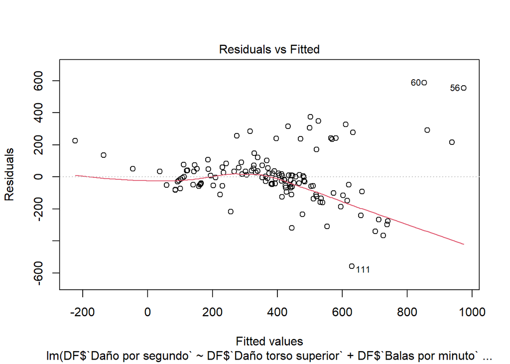

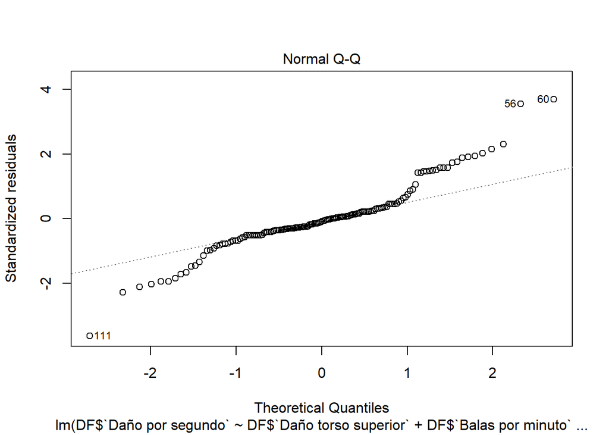

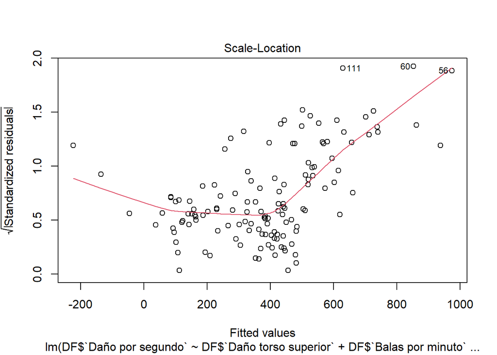

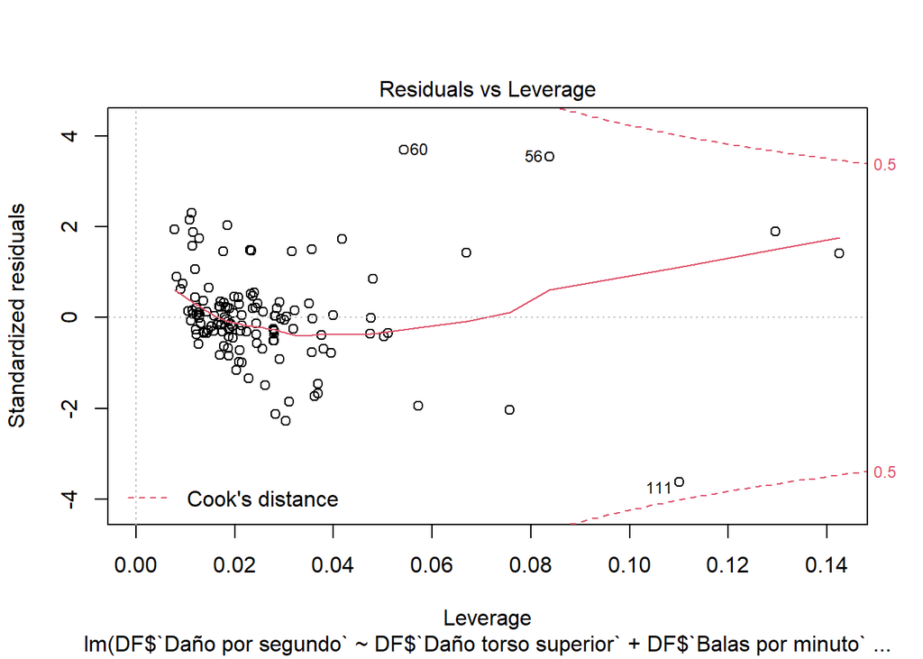

```r
plot(modelo)
```

H0: El modelo es por azar

Ha: El modelo no es por azar

Tras realizar las modificaciones, el p-value del modelo se sigue manteniendo pequeño y el R^2 no ha variado mucho, por lo que concluimos que nuestro modelo final para hallar el daño por segundo teniendo estás variables es: $(2.9356*Daño~torso~superior) + (0.7443*Balas~por~minutos) + (25.2508*Retroceso) - 312.1399$

> **GRÁFICAS DE DIAGNÓSTICO:**

> **CASO DE PREDICCIÓN:**

> 1.- El juego nos habilita poder personalizar armas modificando ciertos parámetros (Daño torso superior, Balas por minuto y Retroceso). Si creamos un arma con un daño de torso superior de 200, balas por minuto de 600 y la media del retroceso de todas las armas de nuestra base de datos. ¿Cuál sería el valor de daño por segundo esperado para esta nueva arma?

```r
mean(DF$Retroceso)
```

```
## [1] 4.046667
```

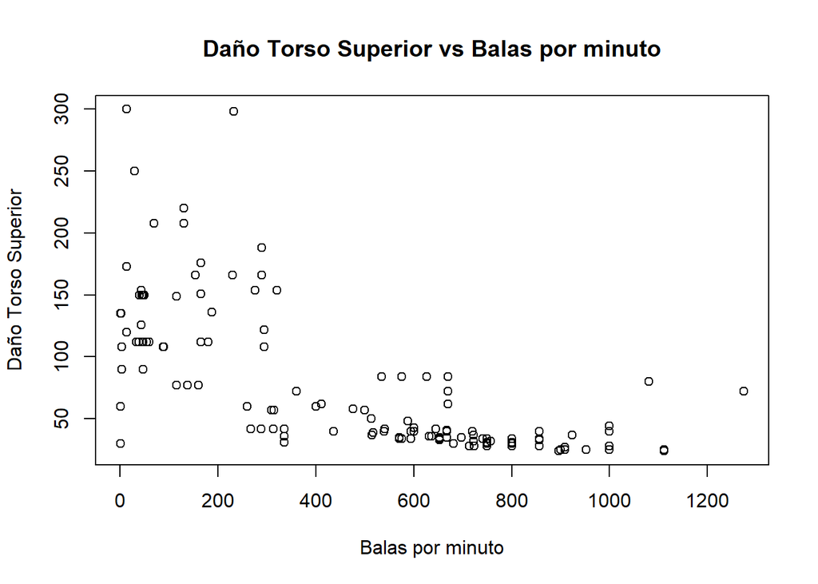

```r
plot(DF$`Daño torso superior`~DF$`Balas por minuto`, main="Daño Torso Superior vs Balas por minuto", ylab = "Daño Torso Superior", xlab = "Balas por minuto")
```

Con este gráfico, se observa que la combinación planteada, no se ha probado en ningún arma actual.

```r
x <- 200
y <- 600
z <- modelo$coefficients[1] + modelo$coefficients[2] * x + modelo$coefficients[3] * y + modelo$coefficients[4] * 4
paste("Daño por segundo: ", round(z,2))
```

```
## [1] "Daño por segundo:  822.58"
```

```r
a <- (DF$`Daño por segundo` > z)
b <- sum(a==TRUE)
b
```

```
## [1] 8
```

Esta nueva arma creada, tendría un valor de daño por segundo de 822.58, el cual supera la media. Además, podemos decir que ocupa el noveno lugar del top 10 de las mejores armas del juego Warzone.

> 2.- Para validar nuestro modelo en el que explica el daño por segundo, escogimos un arma al azar y comparamos el valor real vs la predicción.

```r
arma <- DF[99,]
arma
```

|  | Tipo | Arma | Rango de Daño Máximo (m) | Daño extremidades | Daño Torso inferior | Daño torso superior | Balas por minuto | Daño por segundo | Daño a la cabeza | Retroceso |
| --- | --- | --- | --- | --- | --- | --- | --- | --- | --- | --- |
| 99 | Rifle de Asalto | QBZ-83 | 31 | 28 | 28 | 30 | 681 | 341 | 42 | 4 |

```r
x <- arma$`Daño torso superior`
y <- arma$`Balas por minuto`
z <- arma$Retroceso
w <- modelo$coefficients[1] + modelo$coefficients[2] * x + modelo$coefficients[3] * y + modelo$coefficients[4] * z
paste("Daño por segundo - predicción: ", round(w,2))
```

```
## [1] "Daño por segundo - predicción:  383.82"
```

```r
paste("Daño por segundo real: ", round(arma$`Daño por segundo`,2))
```

```
## [1] "Daño por segundo real:  341"
```

```r
w/arma$`Daño por segundo`-1
```

```
## (Intercept)
##   0.1255754
```

Tras esta prueba, podemos observar que el resultado de la predicción está en un 13% aproximadamente por encima del valor real, lo cual hace sentido con que el modelo exprese el 62% de la variabilidad de la variable ‘Daño por segundo’.

### **Tendencia**

Como ya se ha hallado que las variables que influyen en el ‘Daño por segundo’ son el ‘Daño torso superior’, ‘Balas por minuto’ y ‘Retroceso’, ahora buscamos hallar de alguna forma, cómo se comporta la relación entre ellas.

```r
DFN <- cbind(DF$`Daño torso superior`, DF$`Balas por minuto`, DF$Retroceso)
round(cor(DFN, method = "pearson"), 2)
```

```
##       [,1]  [,2]  [,3]
## [1,]  1.00 -0.71 -0.16
## [2,] -0.71  1.00  0.33
## [3,] -0.16  0.33  1.00
```

Se elaboró una prueba de correlación de Pearson y evidenciamos que hay un coeficiente de Pearson de -0.71 entre las variables ‘Daño torso superior’ y ‘Balas por minuto’. Esto quiere decir que existe una correlación negativa medianamente fuerte entre estas dos variables.

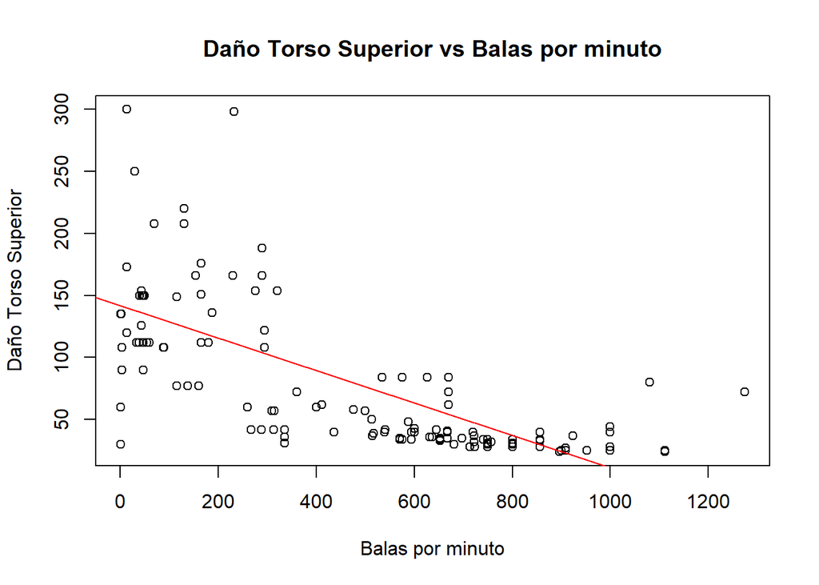

```r
plot(DF$`Daño torso superior`~ DF$`Balas por minuto`, main="Daño Torso Superior vs Balas por minuto", ylab = "Daño Torso Superior", xlab = "Balas por minuto")
modelo <- lm(DF$`Daño torso superior`~ DF$`Balas por minuto`, data = DF)
abline(modelo, col = "red")
```

```r
summary(modelo)
```

```
##
## Call:
## lm(formula = DF$`Daño torso superior` ~ DF$`Balas por minuto`,
##     data = DF)
##
## Residuals:
##      Min       1Q   Median       3Q      Max
## -111.560  -23.142   -7.255   15.766  186.663
##
## Coefficients:
##                        Estimate Std. Error t value Pr(>|t|)
## (Intercept)           141.69117    5.96509   23.75   <2e-16 ***
## DF$`Balas por minuto`  -0.13084    0.01078  -12.14   <2e-16 ***
## ---
## Signif. codes:  0 '***' 0.001 '**' 0.01 '*' 0.05 '.' 0.1 ' ' 1
##
## Residual standard error: 44.28 on 148 degrees of freedom
## Multiple R-squared:  0.4991, Adjusted R-squared:  0.4957
## F-statistic: 147.4 on 1 and 148 DF,  p-value: < 2.2e-16
```

```r
modelo
```

```
##
## Call:
## lm(formula = DF$`Daño torso superior` ~ DF$`Balas por minuto`,
##     data = DF)
##
## Coefficients:
##           (Intercept)  DF$`Balas por minuto`
##              141.6912                -0.1308
```

Luego, se realizó un gráfico en el cual se ve la línea de regresión en color rojo. Vemos que el modelo presenta una tendencia a disminuir el ‘Daño torso superior’ conforme aumenta la cantidad de ‘Balas por minuto’. Además, podemos decir de que cuando las balas logran pasar las mil unidades por minuto, el daño en el torso superior es prácticamente nulo y en algunos casos existen unos valores atípicos. Entonces, cuando tengamos oponentes que cuenten con armas con una gran velocidad de balas por minuto, es muy posible que tengan un bajo daño en el torso superior. Nuestro modelo para hallar el daño en el torso superior es; $(-0.1308*Balas~por~minuto) + 141.6912$

> **PREDICCIÓN:**

Afirmaremos la predicción que mencionamos ya que debería ser correcta para muchos casos, excepto para los valores atípicos. En este caso, usaremos 1100 como valor para las balas por minuto.

```r
x <- 1100
y <- modelo$coefficients[1] + modelo$coefficients[2] * x
paste("Daño torso superior: ", round(y,2))
```

```
## [1] "Daño torso superior:  -2.23"
```

Finalmente, aquí mostramos un criterio de nuestra predicción en el que evidenciamos que al pasar las mil unidades en las balas por minuto, nuestro daño en el torso superior será cercano a cero o menor.

> **Casos atípicos**

```r
DF[DF$`Balas por minuto`>1000, ]
```

|  | Tipo | Arma | Rango de Daño Máximo (m) | Daño extremidades | Daño Torso inferior | Daño torso superior | Balas por minuto | Daño por segundo | Daño a la cabeza | Retroceso |
| --- | --- | --- | --- | --- | --- | --- | --- | --- | --- | --- |
| 56 | Pistola | Amp 63 - Duales | 20.0 | 60 | 60 | 72 | 1274 | 1529 | 76 | 5 |
| 60 | Pistola | CW Magnum - Duales | 31.0 | 80 | 80 | 80 | 1080 | 1440 | 128 | 5 |
| 133 | Subfusil | Fennec | 12.5 | 22 | 25 | 25 | 1111 | 463 | 40 | 6 |
| 138 | Subfusil | Mac-10 | 15.5 | 21 | 24 | 24 | 1111 | 444 | 29 | 5 |

Observamos que 4 armas son las únicas que sobrepasan las mil unidades en las balas por minuto. Por lo tanto, queremos mostrar que nuestro modelo para hallar el daño en el torso superior en estos 4 casos en específico, debería diferir de nuestra tendencia. En este caso, se hizo la prueba con el Subfusil Mac-10.

```r
x <- 1111
y <- modelo$coefficients[1] + modelo$coefficients[2] * x
paste("Daño torso superior: ", round(y,2))
```

```
## [1] "Daño torso superior:  -3.67"
```

Concluimos que para valores atípicos como los previamente mencionados, el daño en el torso superior no corresponde a la tendencia hallada ya que el valor es mayor a cero.

> **Relación entre ‘Retroceso’ y ‘Balas por minuto’**

Es interesante analizar estas dos variables ya que podría explicar la disminución del daño en el torso superior al aumentar las balas por minuto.

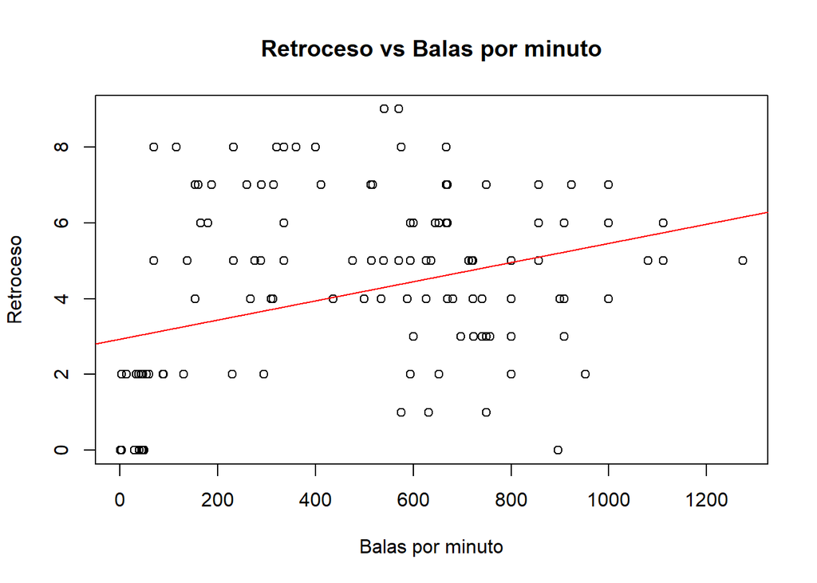

```r
plot(DF$Retroceso ~ DF$`Balas por minuto`, main="Retroceso vs Balas por minuto", ylab = "Retroceso", xlab = "Balas por minuto")
modelo <- lm(DF$Retroceso ~ DF$`Balas por minuto`, data = DF)
abline(modelo, col = "red")
```

```r
cor(DF$`Balas por minuto`, DF$Retroceso)
```

```
## [1] 0.3322043
```

Podemos decir que existe una correlación positiva débil entre las variables ‘Retroceso’ y ‘Balas por minuto’, la cual quiere decir que es indistinto que el arma tenga un gran cantidad de balas por minuto ya que no influye fuertemente en el retroceso; es decir, en la dificultad que se tendrá para dominar el arma. Por lo tanto, que el daño en el torso superior disminuya conforme aumentan las balas por minuto, tal vez se deba a una convención del juego ya que no consideran “justo” que un arma tenga un alto daño y un alto valor de balas por minuto porque significaría que un jugador pueda matar a sus oponentes de manera muy rápida y el juego perdería su objetivo de crear batallas.

### **Conclusiones**

> - Se identificó una relación entre los distintos daños que se generan a las diversas zonas del cuerpo, encontrando una prioridad en la zona objetivo para causar un daño efectivo al oponente.
> - Nuestro modelo final explica alrededor del 62 % de la variabilidad de la variable ‘Daño por segundo’; es decir, encontramos una correlación relativamente alta con la cual podremos hallar valores predictivos razonables para nuestras armas en base al daño el torso superior, las balas por minuto y el retroceso.
> - En el experimento retroceso, una variable externa a la base de datos obtenida, se ha evidenciado una relación estadísticamente significativa con el daño por segundo.

### **Anexo**

**Experimento Retroceso**

[figure not shown]

Encontramos una pared sin manchas de disparos para que podamos ver claramente la tendecia que forman los disparos.

[figure not shown]

Una vez hecho el experimento, evaluamos la escala del 0 al 10 según los criterios previamente mencionados.

### **Factibilidad**

> **Diagrama de Gantt**

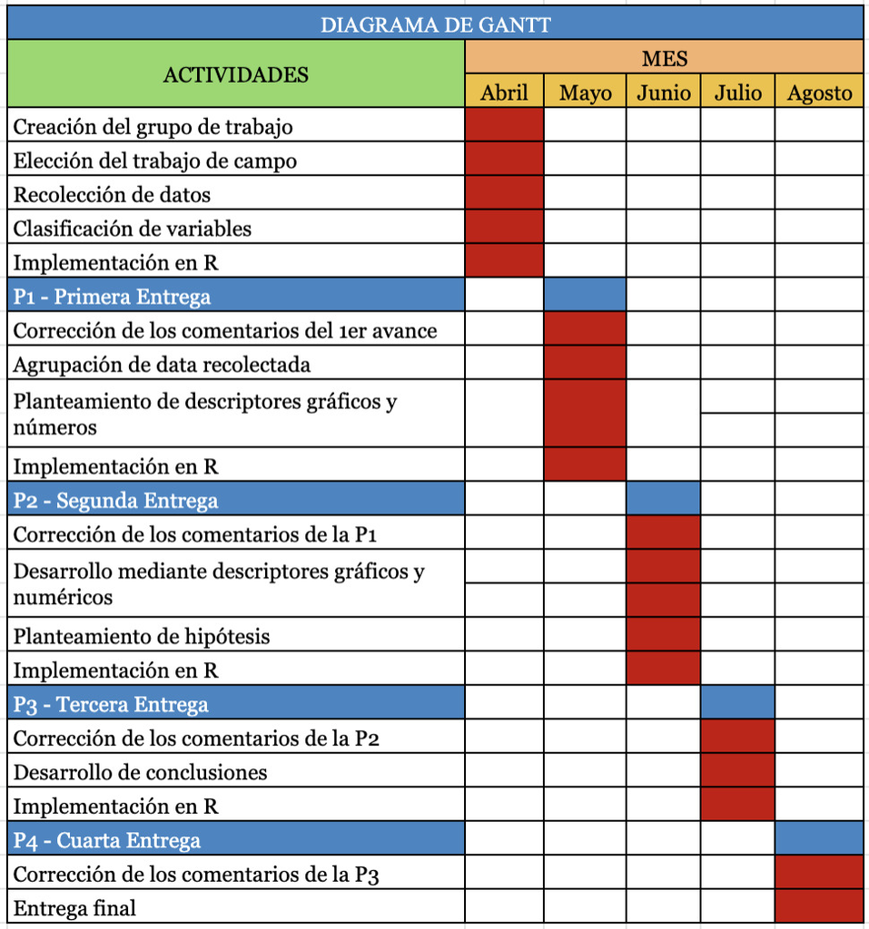

*Diagrama de gantt reducido en tiempo real de acuerdo con las entregas correspondientes*

[interactive chart not shown]